# ImagePlotting: a tidyverse compatible, comprehensive appraoch

Bonnell, Faltesek, Gates, Lohberger

9/15/2021

## Why Image Plotting?

In 2011, Lev Manovich and the Software Studies Initiative released a macro known as [Image Plot](http://lab.softwarestudies.com/p/imageplot.html) for ImageJ. When combined with a system for measuring the properties of images, the macro allowed users to compose an Image Plot, where the images that they were analyzing would appear themselves as the points of a scatterplot. This is an extremely useful way to analyze visual data as it allows everyone to see the both a meta representation of information about the optical qualities of the images while experiencing them visually. The original documentation focused on patterns of change through an artists collection, for example, how did the works of Mondrain or VanGoh (sample datasets from Image Plot) change through the years?

Underlying much of the rise of Cultural Analytics is the tension between close and distant reading which is often overplayed. The close reading of a particular image will always be an important project, what distant reading methods can provide are: ways of visualizing entire collections, tests for normative claims to clustering or trends, generative documents for encouraging new hypothesis formation. In this sense, the plots produced as image plots appear very much like marginalia in reading or notes taken during field work.

We designed this package to interface with the tidyverse more generally, all of our measurements are collected in dataframes with one case per row, our tables can easily be joined to make a very wide dataframe. The end plotting logic of this package is geom_image for ggplot2. If you are functional with dplyr and ggplot2, this package should provide you with a comprehensive set of image plotting tools.

```r
knitr::opts_chunk$set(echo = TRUE)
knitr::opts_chunk$set(include = TRUE)

#our package
library(ImagePlotX)
```

### Importing

Our basic importer function takes the name of your folder in quotes and yields a dataframe with each local and global path. This basic loader does not do anything to the images or even read them, it is a simplifier that helps you know where your files actually are.

```r
#where you can find your mittens...
#https://danielfaltesek.com/mittens.zip

#Open this in your downloads. I am a mac user, so it appears here...
A<-"/Users/faltesed/Downloads/mittens"
load_images(A)
```

```
##  [1] "/Users/faltesed/Downloads/mittens/A.jpg"
##  [2] "/Users/faltesed/Downloads/mittens/B.jpg"
##  [3] "/Users/faltesed/Downloads/mittens/C.jpg"
##  [4] "/Users/faltesed/Downloads/mittens/D.jpg"
##  [5] "/Users/faltesed/Downloads/mittens/E.png"
##  [6] "/Users/faltesed/Downloads/mittens/F.jpg"
##  [7] "/Users/faltesed/Downloads/mittens/G.jpg"
##  [8] "/Users/faltesed/Downloads/mittens/H.jpg"
##  [9] "/Users/faltesed/Downloads/mittens/I.jpg"
## [10] "/Users/faltesed/Downloads/mittens/J.jpg"
## [11] "/Users/faltesed/Downloads/mittens/K.jpg"
## [12] "/Users/faltesed/Downloads/mittens/L.jpg"
## [13] "/Users/faltesed/Downloads/mittens/M.jpg"
## [14] "/Users/faltesed/Downloads/mittens/N.jpg"
## [15] "/Users/faltesed/Downloads/mittens/O.jpg"
## [16] "/Users/faltesed/Downloads/mittens/Original.jpg"
## [17] "/Users/faltesed/Downloads/mittens/P.jpg"
## [18] "/Users/faltesed/Downloads/mittens/Q.jpg"
## [19] "/Users/faltesed/Downloads/mittens/R.jpg"
```

So far, you have downloaded a folder of images, and successfully used our initial loader function. This isn’t a loader as much as a documentary function that helps you start to keep track of where files live on your computer. When you load your own images, you will need to change the address in that last chunk to include your directory of images.

For ease in analysis and discussion, each of the images has a single letter label. The original is labeled, original.

This package is a bit CRAN risky, as some of the most interesting features require that we write some files on your computer, rather than storing them in your memory.

```r
convert_and_import(images)
```

This is always your starting point, which is helpful as it yields an entry in your global environment. It is often helpful to have your files in a single format, which in our case would be PNG. Our function convert_and_import will take the result of your load_images and will convert all of your images to PNG it will put them in a single folder named “converted” in the home directory of your R project. Each image will be assigned a new filename which is a random combination of numbers and letters, which is associated with the original name for that file.

WARNING: if you run convert and import multiple times, your converted directory will get larger and larger. In accordance with tidy principals our functions are non-destructive. Furthermore, we can imagine use cases where you might chose to convert and land in a single directory for further analysis. If you want to have a clean convert_and_import, delete the directory between function runs.

You can take a look at some of the individual converted Bernies by opening your “converted” directory, selecting an image with the radio button, and then using the “more” dropdown to open the image in another program. You can see that the images were successfully converted.

[figure not shown]

At that point, your convert_and_import function will reproduce the directory with your fresh new files.

### Basic Measurement

Once your images are imported you need to measure them in some way. Your first step in measurement is measure_images, which predictably produces a dataframe called measured_images. This function can tell you many fun things about your images, like what kind of files they are (if you have not converted), their dimensions, color spaces, filesizes, and will OCR any text on the image. This can be very useful for the analysis of memes, our Bernie pictures have no text.

A second useful measurement method is fluency analysis, which employs the methods from the image fluency package, fielding a dataframe with contrast, self_similarity, symmetry, and complexity. This is a slower function that many others, but can produce really useful results for your analysis.

```r
measure_images(converted_images)
```

```
## [1] "OCR results may be misleading if images include no text"
```

```r
fluency(converted_images)
```

In this package we have also created other functions that compute numbers like these, for your uses you will need to work with each function and your dataframes and determine which provide the answers that help you develop your project.

#### Your First Plot

```r
#for pedagogical reasons, we typically call each tidy package individually
library(dplyr)
```

[figure not shown]

```r
library(ggplot2)

#combine the data side by side
mypictures<-bind_cols(converted_images, measured_images)

#we can also attach the other measurements


#the plotting code, be sure to use your quotation marks
#the number at the end is your alpha, or transparency number
imageplot_output("mypictures", "a", "info.filesize", .5)
```

## Colors

Colors are great fun and are also very useful. Our color methods are in a single function called color_analysis yielding a dataframe color_results. Under the hood, we are using a number of calculations from both RGB and HSV, depending on your needs.

Basic Colors mean_red Deviation_red Mean_green Deviation_green Mean_blue Deviation_blue

### Color Theory

To understand what these measure we need to take a detour into some color theory. In many primary schools the primary colors are taught as red, blue, and yellow. For subtractive color and rudimentary paints this then leads to a series of mixing choices and lovely paintings. More advanced versions of this, such as in offset printing, use cyan, magenta, and yellow, often with a layer of black to save money and produce higher contrast line effects, thus CMYK. There are colors where this is not quite as consistent and sharp as we may like which leads to more specific inks, Pantones and the like. With light, we are adding colors to produce white.

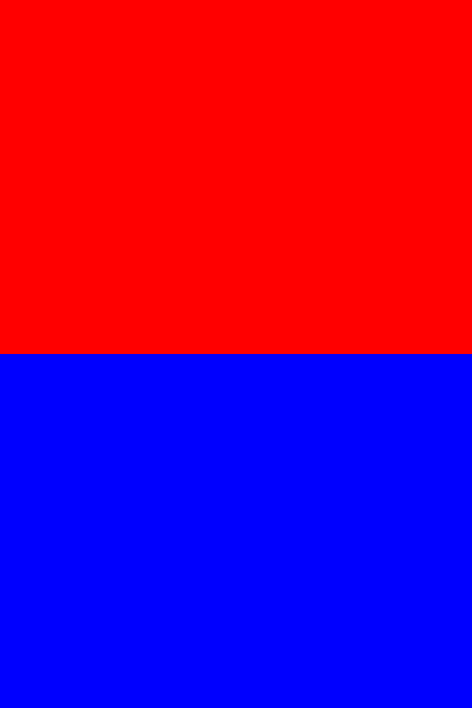

red and blue block image.

Let’s use this one image for our analysis:

```r
dir.create("colors")
```

```r
download.file("https://www.danielfaltesek.com/colorblock.png", "colors/colorblock2.png")
C<-load_images("~colors")
```

```
## [1] "~colors/colorblock2.png"
```

```r
library(dplyr)
color_analysis(C)
colors_results
```

```
##   mean_red deviation_red mean_blue deviation_blue mean_green deviation_green
## 1    127.5      127.5001     127.5       127.5001          0               0
##    mean_hue deviation_hue mean_saturation deviation_saturation mean_value
## 1 0.3333333     0.3333336               1                    0          1
##   deviation_saturation.1 luminance lum_contrast hue_region
## 1                      0        85     85.00008       Rose
```

The results of the analysis should be clear here. This is an RGB image, half of which is red, and half of which is blue. Notice that the red and blue are each 127.5 which is half of the total value (which makes sense given that half the image is purely that color). The standard deviations also read as half of the value. Green does not appear in this image.

Hue, saturation, and value provide another useful set of measurements for color. We can imagine use cases where you might prefer to use these factors rather than thinking about which raw RGB specifications. For example, it might be helpful to look for trends in saturation or comparing saturation and the use of a certain color, like red. While it would be possible to ask users to calculate their own transformations between RGB and HSV, we simply provide all in the dataframe for speed and convenience.

The HSL values are less and more useful depending on your needs. The saturation of our image is total, 1. The hue is .333333 with a deviation of .333336. Hue is unhelpful in this case compared with RGB. Image level hue is less useful in this case. Hue regions are [teteriary](https://en.wikipedia.org/wiki/Tertiary_color) which are helpful for understanding the general family of colors present.

You could select images where rose is the color family, the blue value is low, and the saturation is less than half to find pale pinks with a simple pipe. In a future version detection schemes for quaternary colors, jewel tones, pastels, and segmented regions may be added, if there is interest.

#### Color Plotting

```r
color_analysis(converted_images)
head(colors_results)
```

```
##    mean_red deviation_red mean_blue deviation_blue mean_green deviation_green
## 1  88.03879      50.50799  52.42174       39.39110   69.99647        49.37203
## 2 111.51838     108.84900 114.48620       88.03052  104.99191        90.66390
## 3  65.21476      90.48715  43.34958       74.11275   63.92489        90.36359
## 4  77.07664      72.84817  76.63221       74.23997   78.57176        66.75985
## 5 117.11502      82.31252  88.79870       66.00366  102.35877        58.17986
## 6  78.13561      80.69728 146.42576       67.38305  135.90211        70.78823
##    mean_hue deviation_hue mean_saturation deviation_saturation mean_value
## 1 0.2701136     0.3301250       0.4579164            0.2571795  0.3486168
## 2 0.3169398     0.3411196       0.4319762            0.4063933  0.5089563
## 3 0.3290329     0.2867701       0.7819609            0.3345989  0.3357170
## 4 0.4435929     0.2698108       0.5810582            0.2449151  0.4333243
## 5 0.4072590     0.3228703       0.5595321            0.3361771  0.5620809
## 6 0.4942101     0.1721235       0.5403596            0.3417009  0.5946377
##   deviation_saturation.1 luminance lum_contrast hue_region
## 1              0.2571795  70.15233     46.42371     Orange
## 2              0.4063933 110.33217     95.84781     Violet
## 3              0.3345989  57.49641     84.98783     Orange
## 4              0.2449151  77.42687     71.28266 Chartreuse
## 5              0.3361771 102.75750     68.83201     Orange
## 6              0.3417009 120.15449     72.95619       Rose
```

Interestingly the images produced by the system have distinct appearances.

[figure not shown]

```r
mypictures<-bind_cols(mypictures, colors_results)
imageplot_output("mypictures", "mean_red", "mean_blue", .5)
```

We can see that the bright yellow/white image has quite a bit of both red and blue, while key outliers in blue and red are clearly found in the corners. A mean red~blue plot is also generally a lightness detector.

##Porportion and Balance and Line

If you strategically blur the channels of an image, distortions in red, green, or blue will have minimal impact on your perception. Distorting the black/white or K channel has a dramatic impact. For many years this lead teachers of media production to teach that line as described through black/white is the primary mode of visual processing.

[figure not shown]

M. Chirimuta offers a variety of arguments against such a separation and layering, focusing especially on abundant evidence that visual processing is highly synergistic. What we might think of as optical illusions or weaknesses in visual systems are artifacts of the attempt to detect edges (a critical task for survival). The functions presented in this section are intended to help with the analysis of lines and edges.

### Symmetry_anaylsis.

The symmetry method relies on canny edge detection with averaging, standard deviation, and subtraction of the regions in question. This does not provide a direct 1:1 symmetry, but sees edgyness in balance as the key indicator of symmetry. If we take a quick sketch of a

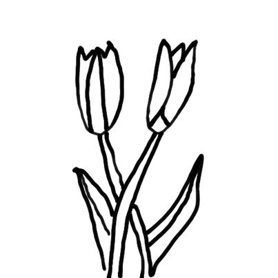

we would notice that each side has a similar number of petals and leaves, this would be symmetrical in this model.

Our symmetry method yields a horizontal measure and a vertical measure. These also include standard deviation numbers. A very low sd would suggest a few heavy thick edges, which could be useful in the analysis of visual noise. We also include a symmetry function which folds the image from the top left corner to the bottom right corner, measuring symmetry along an integral line y~x.

For all of these symmetry analyses, if regions have no canny edges, there will be errors.

```r
symmetry_analysis(converted_images)
```

```
##     a        horiz    sd_top sd_bottom vert   sd_left  sd_right
## 1   1 -0.011852502 0.4064274 0.4161762    0 0.4024834 0.4024834
## 2   2 -0.006694469 0.2736789 0.2846854    0 0.2674252 0.2674252
## 3   3  0.076602283 0.3498663 0.2495093    0 0.3055756 0.3055756
## 4   4  0.033472344 0.2427677 0.1695823    0 0.2284608 0.2284608
## 5   5  0.034021071 0.3189229 0.2736623    0 0.3164348 0.3164348
## 6   6 -0.018327480 0.1345336 0.1888793    0 0.1453526 0.1453526
## 7   7  0.013279192 0.2704635 0.2495093    0 0.2387569 0.2387569
## 8   8 -0.025570676 0.2784850 0.3144141    0 0.2971061 0.2971061
## 9   9  0.009328358 0.2520202 0.2361640    0 0.2547780 0.2547780
## 10 10 -0.023156277 0.3119029 0.3401269    0 0.3092852 0.3092852
## 11 11 -0.004170325 0.1958462 0.2061156    0 0.1716659 0.1716659
## 12 12  0.060140474 0.3480642 0.2736623    0 0.3114831 0.3114831
## 13 13  0.033472344 0.2427677 0.1695823    0 0.2284608 0.2284608
## 14 14  0.008779631 0.3057539 0.2951127    0 0.2684293 0.2684293
```

[output cut: 25 more lines]

```r
#please halp
fluency_results<-unique(fluency_results)
```

Tendency toward zero is an indicator of symmetry while negative and positive values can suggest where images are heavier.

### Thirds_analysis

This is our approach for reading images for the use of a standard set of composition trends known as the rule of thirds. Generally, people like images where the most important figure is on a third line, like something of a tic-tac-toe grid. The stick figure

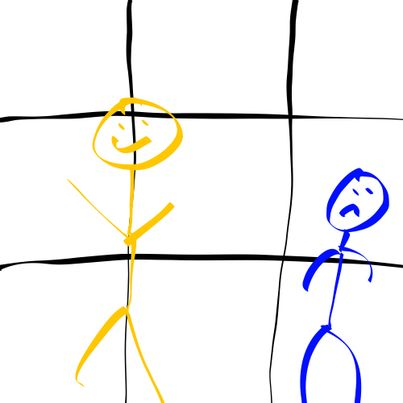

is on a third line.

This function segments each image into four thirds regions which are then compared for canny edges so that we can compare. Negative scores mean that there is more activity not on the third, positive scores mean there is more there than the other third. If all scores are very low, it is likely that the image does not conform to the rule of thirds.

Notice that we have two discrete outputs which tell you which thirds were highest. These are simply there to avoid a calculation for you. In a few cases, the neural net did shift the thirds, meaning that core composition elements did change.

```r
thirds_images(converted_images)
```

```
## [1] 0.009024704
## [1] 0.01743355
## [1] 0.01153452
## [1] -0.01840909
## [1] -0.007858339
## [1] -0.009440681
## [1] -0.002358848
## [1] -0.02606116
## [1] 0.05861109
## [1] 0.02539905
## [1] 0.01589446
## [1] -0.005910762
## [1] 0.005858146
## [1] 0.02268822
## [1] -0.01175179
```

[output cut: 81 more lines]

### Edges_analysis

This is by far our largest measurement dataframe Includes a region by region breakdown of the canny edges detected in each region and the relative standard deviation of the edges in that region. Each region also has a skewness measure and a kurtosis measure, which speak to how much in any given region the distribution leans and how peaky it is.

The use cases for this particular model would include looking at images for particular regions where there is a higher density of activity or looking for defocused or empty areas. An approach looking for images that are blue with low edge values in regions 1-4 would be a “sky” detector. If faces were known to be in the images and thirds were established, the scores for R8 and R 12 could be used to look for lead room. There are many ways that you can imagine using this approach to compare particular areas across a set of images, we hope this particular result, while voluminous, is flexible.

Each represents one-sixteenth of the image numbered in rows from the top left corner, which is R1. The extreme bottom right is R16.

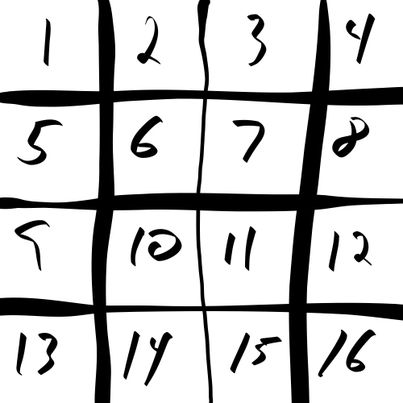

It is straight forward to write new functions that could approximate symmetry or focus detection Note: it is not uncommon for this function to throw NaN when there are regions of the graphic with no edges. This is a drawback of our method.

```r
edge_analysis(converted_images)
```

```
## [1] "edge analysis complete"
```

##Outputs and Aesthetics

So far you are familiar with our basic plotting function. This is intended to help folks who are unfamilar create meaningful plots.

Within the function there are really three distinct things happening: A. a function is “passing alpha” to adjust the transparency of your images. B. a ggplot2 object is using the standard grammar of graphics approach to build a plot C. the library ggimage is being used to append the images with modified alpha, which requires a specific assignment of file names

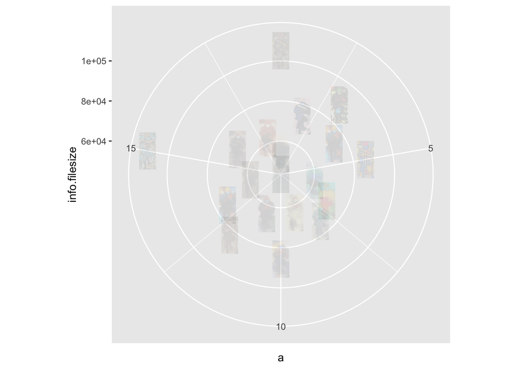

```r
library(ggplot2)
#sub-routine A is passing alpha
transparent <- function(img){magick::image_fx(img, expression= ".1*a", channel = "alpha")}
#B is the basic GG plot
ggplot(mypictures, aes(a, info.filesize))+
  #and C is the geom
  ggimage::geom_image(image=mypictures$local_path,image_fun=transparent) + coord_polar()
```

### Styles

Because we are using the gg paradigm for producing output graphics, all of your strategies for using ggplot2 can be used here as well. Because we are using a particular geom, we can’t play with many of the options on the front side of the cheatsheet. The back right hand side, is going to be where the fun begins.

[figure not shown]

```r
#for style sake
library(ggthemes)

#old stuff
transparent <- function(img){magick::image_fx(img, expression= ".1*a", channel = "alpha")}
ggplot(mypictures, aes(a, info.filesize))+
  ggimage::geom_image(image=mypictures$local_path,image_fun=transparent) +
  #newstuff
  #let's make this polar with a linedrawn background and a big title
  coord_polar()+theme_solarized() +labs(title = "Mittens Are Warm.")
```

While aesthetics aren’t perfect here, you can start to see how for things like a symmetry plot or other times when we are looking for outliers a polar plot could be really powerful.

### Facets

[figure not shown]

```r
#old stuff
transparent <- function(img){magick::image_fx(img, expression= ".7*a", channel = "alpha")}

#let's make some random numbers for use as a discrete variable
#we are using the base R to call for the first dimension, becuase yo
randoms<-rnorm(dim(mypictures)[1], 1:4)

#we can mutate to attach, as integer will resolve those pesky decimals
mypictures<-mypictures%>%
  mutate("Category" = as.integer(randoms))

ggplot(mypictures, aes(a, info.filesize))+
  ggimage::geom_image(image=mypictures$local_path,image_fun=transparent) +
  #newstuff
  #no styling, but definitely faceting
  facet_wrap(~Category)
```

The use cases for facets with image plots are only limited by your imagination.

## Expanded Use Cases

You can extend this package to use any data by simply joining it to your primary dataframe. In these examples we typically joined single frames together. You can just as easily bind many dataframes.

```r
wide_results<-bind_cols(converted_images, colors_results, measured_images,symmetry_images, thirds_results, edge_results)
```

```
## * local_path -> local_path...1
## * a -> a...18
## * a -> a...27
## * a -> a...37
## * local_path -> local_path...44
```

```r
glimpse(wide_results)
```

```
## Rows: 19
## Columns: 111
## $ local_path...1         <chr> "converted/1KVBS.png", "converted/7c42q.png", "…
## $ old_local_path         <chr> "/Users/faltesed/Downloads/mittens/A.jpg", "/Us…
## $ mean_red               <dbl> 88.03879, 111.51838, 65.21476, 77.07664, 117.11…
## $ deviation_red          <dbl> 50.50799, 108.84900, 90.48715, 72.84817, 82.312…
## $ mean_blue              <dbl> 52.42174, 114.48620, 43.34958, 76.63221, 88.798…
## $ deviation_blue         <dbl> 39.39110, 88.03052, 74.11275, 74.23997, 66.0036…
## $ mean_green             <dbl> 69.99647, 104.99191, 63.92489, 78.57176, 102.35…
## $ deviation_green        <dbl> 49.37203, 90.66390, 90.36359, 66.75985, 58.1798…
## $ mean_hue               <dbl> 0.27011363, 0.31693983, 0.32903292, 0.44359286,…
## $ deviation_hue          <dbl> 0.33012500, 0.34111958, 0.28677013, 0.26981075,…
## $ mean_saturation        <dbl> 0.4579164, 0.4319762, 0.7819609, 0.5810582, 0.5…
## $ deviation_saturation   <dbl> 0.2571795, 0.4063933, 0.3345989, 0.2449151, 0.3…
## $ mean_value             <dbl> 0.3486168, 0.5089563, 0.3357170, 0.4333243, 0.5…
```

[output cut: 98 more lines]

### Montage

If we want a simple montage, we could assign some random years to our images. You would likely want to find a variable that then places your images side by side, such as a rank ordering. this can be accomplished by using “rank(mean_blue)” to convert what would be overlapping or overly spacey points.